# Презентация по лабораторной работе №3

Основы информационной безопасности

Мажитов М. А.

Российский университет дружбы народов, Москва, Россия

21 сентября 2024

## Докладчик

- Мажитов Магомед Асхабович
- студент группы НКНбд-01-21
- Российский университет дружбы народов

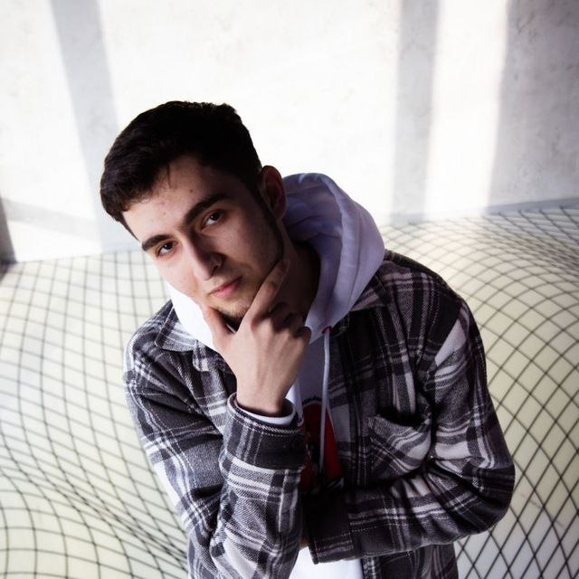

## Цель

Получить практические навыки работы в консоли с атрибутами файлов для групп пользователей.

## Выполнение лабораторной работы.

Создаю гостевые учетные записи *guest* и *guest2*, а также задаю им пароли.

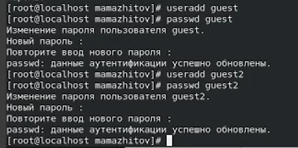

Создание пользователей

Добавляю пользователя *guest2* в группу guest.

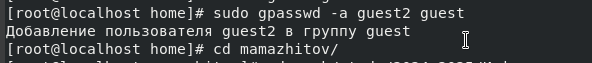

Добавление guest2 в группу guest

Выполнил вход в систему от двух пользователей на двух разных консолях: *guest* на первой консоли и *guest2* на второй консоли. Далее определил директорию, в котором мы находимся, для каждого пользователя с помощью команды *pwd*.(

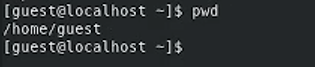

Просмотр директории

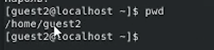

Просмотр директории

С помощью команды *whoami* уточнил имя пользователя в каждом терминале.

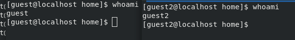

Имя пользователя

Определил командами *groups guest* и *groups guest2*, в какие группы входят пользователи *guest* и *guest2*.

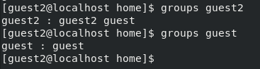

Группы пользователей

Как мы видим на скриншоте, *guest2* входит в группы *guest2*(созданная автоматически) и *guest*(добавили вручную), а *guest* входит в группу *guest*.

С помощью команды *cat /etc/group | grep ‘guest’* вывел интересующую нас информацию файла *group*.

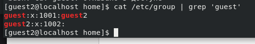

Содрежание файла group

От имени пользователя *guest2* выполнил регистрацию пользователя *guest2* в группе *guest* командой *newgrp guest*.

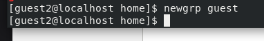

Регистрация guest2 в группе guest

От имени пользователя *guest* измените права директории */home/guest*, разрешив все действия для пользователей группы.

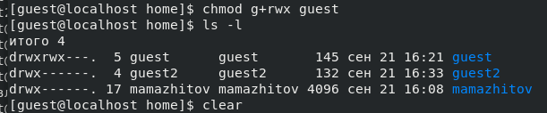

Изменение прав доступа директории guest

От имени пользователя guest снял с директории */home/guest/dir1* все атрибуты командой *chmod 000 dirl*.

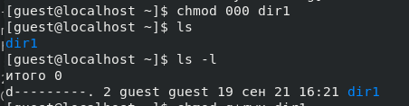

## Заполнение таблицы 3.2

| Операция | Права на директорию | Права на файл |
| --- | --- | --- |
| Создание файла | `d----wx-— (030)` | `--------— (000)` |
| Удаление файла | `d----wx-— (030)` | `--------— (000)` |
| Чтение файла | `d-----x-— (010)` | `----r---— (040)` |
| Запись в файл | `d-----x-— (010)` | `-----w--— (020)` |
| Переименование файла | `d----wx-— (030)` | `--------— (000)` |
| Создание поддиректории | `d----wx-— (030)` | `--------— (000)` |
| Удаление поддиректории | `d----wx-— (030)` | `--------— (000)` |

## Вывод

Были получены практические навыки работы в консоли с атрибутами файлов для групп пользователей.

## Список литературы. Библиография

[0] Методические материалы курса

[1] Права доступа: https://codechick.io/tutorials/unix-linux/unix-linux-permissions

[2] Группы пользователей: https://losst.pro/gruppy-polzovatelej-linux#Что_такое_группы